# Project_Full_Code_Notebook_EasyVisa_final

[figure not shown]

Artificial Intelligence and Machine Learning

Ensemble Techniques and Model Tuning

[figure not shown]

Visa Approval Facilitation

# **Problem Statement**

## Context

Business communities in the United States are facing high demand for human resources, but one of the constant challenges is identifying and attracting the right talent, which is perhaps the most important element in remaining competitive. Companies in the United States look for hard-working, talented, and qualified individuals both locally as well as abroad.

The Immigration and Nationality Act (INA) of the US permits foreign workers to come to the United States to work on either a temporary or permanent basis. The act also protects US workers against adverse impacts on their wages or working conditions by ensuring US employers' compliance with statutory requirements when they hire foreign workers to fill workforce shortages. The immigration programs are administered by the Office of Foreign Labor Certification (OFLC).

OFLC processes job certification applications for employers seeking to bring foreign workers into the United States and grants certifications in those cases where employers can demonstrate that there are not sufficient US workers available to perform the work at wages that meet or exceed the wage paid for the occupation in the area of intended employment.

## Objective

In FY 2016, the OFLC processed 775,979 employer applications for 1,699,957 positions for temporary and permanent labor certifications. This was a nine percent increase in the overall number of processed applications from the previous year. The process of reviewing every case is becoming a tedious task as the number of applicants is increasing every year.

The increasing number of applicants every year calls for a Machine Learning based solution that can help in shortlisting the candidates having higher chances of VISA approval. OFLC has hired the firm EasyVisa for data-driven solutions. You as a data scientist at EasyVisa have to analyze the data provided and, with the help of a classification model:

- Facilitate the process of visa approvals.
- Recommend a suitable profile for the applicants for whom the visa should be certified or denied based on the drivers that significantly influence the case status.

## Data Description

The data contains the different attributes of employee and the employer. The detailed data dictionary is given below.

- case_id: ID of each visa application
- continent: Information of continent the employee
- education_of_employee: Information of education of the employee
- has_job_experience: Does the employee has any job experience? Y= Yes; N = No
- requires_job_training: Does the employee require any job training? Y = Yes; N = No
- no_of_employees: Number of employees in the employer's company
- yr_of_estab: Year in which the employer's company was established
- region_of_employment: Information of foreign worker's intended region of employment in the US.
- prevailing_wage: Average wage paid to similarly employed workers in a specific occupation in the area of intended employment. The purpose of the prevailing wage is to ensure that the foreign worker is not underpaid compared to other workers offering the same or similar service in the same area of employment.
- unit_of_wage: Unit of prevailing wage. Values include Hourly, Weekly, Monthly, and Yearly.
- full_time_position: Is the position of work full-time? Y = Full Time Position; N = Part Time Position
- case_status: Flag indicating if the Visa was certified or denied

# **Importing necessary libraries**

```python
# Installing the libraries with the specified version.
%pip install numpy==2.0.2 pandas==2.2.2 scikit-learn==1.6.1 matplotlib==3.10.0 seaborn==0.13.2 xgboost==3.0.5 imbalanced-learn==0.12.4 -q --user
```

**Note**: *After running the above cell, kindly restart the notebook kernel and run all cells sequentially from the start again.*

```python
import warnings

warnings.filterwarnings("ignore")

# Libraries to help with reading and manipulating data
import numpy as np
import pandas as pd

# Library to split data
from sklearn.model_selection import train_test_split

# libaries to help with data visualization
import matplotlib.pyplot as plt
import seaborn as sns

# Removes the limit for the number of displayed columns
pd.set_option("display.max_columns", None)
# Sets the limit for the number of displayed rows
pd.set_option("display.max_rows", 100)

# To oversample and undersample data
from imblearn.over_sampling import SMOTE
from imblearn.under_sampling import RandomUnderSampler

# Libraries different ensemble classifiers
from sklearn.ensemble import (
    BaggingClassifier,
    RandomForestClassifier,
    AdaBoostClassifier,
    GradientBoostingClassifier,
    StackingClassifier,
)

from xgboost import XGBClassifier
from sklearn.tree import DecisionTreeClassifier

# Libraries to get different metric scores
from sklearn import metrics
from sklearn.metrics import (
    confusion_matrix,
    accuracy_score,
    precision_score,
    recall_score,
    f1_score,
)

# To tune different models
from sklearn.model_selection import GridSearchCV
```

# **Loading the dataset**

```python
visaData = pd.read_csv('./EasyVisa.csv')
# copying data to another variable to avoid any changes to original data
data = visaData.copy()
```

# **Overview of the Dataset**

- Observations
- Sanity checks

```python
# First 5 rows of the data
data.head()
```

|  | case_id | continent | education_of_employee | has_job_experience | requires_job_training | no_of_employees | yr_of_estab | region_of_employment | prevailing_wage | unit_of_wage | full_time_position | case_status |
| --- | --- | --- | --- | --- | --- | --- | --- | --- | --- | --- | --- | --- |
| 0 | EZYV01 | Asia | High School | N | N | 14513 | 2007 | West | 592.2029 | Hour | Y | Denied |
| 1 | EZYV02 | Asia | Master's | Y | N | 2412 | 2002 | Northeast | 83425.6500 | Year | Y | Certified |
| 2 | EZYV03 | Asia | Bachelor's | N | Y | 44444 | 2008 | West | 122996.8600 | Year | Y | Denied |
| 3 | EZYV04 | Asia | Bachelor's | N | N | 98 | 1897 | West | 83434.0300 | Year | Y | Denied |
| 4 | EZYV05 | Africa | Master's | Y | N | 1082 | 2005 | South | 149907.3900 | Year | Y | Certified |

```python
# Last 5 rows of the data
data.tail()
```

|  | case_id | continent | education_of_employee | has_job_experience | requires_job_training | no_of_employees | yr_of_estab | region_of_employment | prevailing_wage | unit_of_wage | full_time_position | case_status |
| --- | --- | --- | --- | --- | --- | --- | --- | --- | --- | --- | --- | --- |
| 25475 | EZYV25476 | Asia | Bachelor's | Y | Y | 2601 | 2008 | South | 77092.57 | Year | Y | Certified |
| 25476 | EZYV25477 | Asia | High School | Y | N | 3274 | 2006 | Northeast | 279174.79 | Year | Y | Certified |
| 25477 | EZYV25478 | Asia | Master's | Y | N | 1121 | 1910 | South | 146298.85 | Year | N | Certified |
| 25478 | EZYV25479 | Asia | Master's | Y | Y | 1918 | 1887 | West | 86154.77 | Year | Y | Certified |
| 25479 | EZYV25480 | Asia | Bachelor's | Y | N | 3195 | 1960 | Midwest | 70876.91 | Year | Y | Certified |

```python
# dimensions of the data
print("Number of rows: ", data.shape[0])
print("Number of columns: ", data.shape[1])
```

```
Number of rows:  25480
Number of columns:  12
```

```python
# Check the data types of the columns
data.info()
```

```
<class 'pandas.core.frame.DataFrame'>
RangeIndex: 25480 entries, 0 to 25479
Data columns (total 12 columns):
 #   Column                 Non-Null Count  Dtype
---  ------                 --------------  -----
 0   case_id                25480 non-null  object
 1   continent              25480 non-null  object
 2   education_of_employee  25480 non-null  object
 3   has_job_experience     25480 non-null  object
 4   requires_job_training  25480 non-null  object
 5   no_of_employees        25480 non-null  int64
 6   yr_of_estab            25480 non-null  int64
 7   region_of_employment   25480 non-null  object
 8   prevailing_wage        25480 non-null  float64
 9   unit_of_wage           25480 non-null  object
 10  full_time_position     25480 non-null  object
 11  case_status            25480 non-null  object
dtypes: float64(1), int64(2), object(9)
memory usage: 2.3+ MB
```

#### Fixing the data types

```python
cols = data.select_dtypes(['object'])
cols.columns
```

```
Index(['case_id', 'continent', 'education_of_employee', 'has_job_experience',
       'requires_job_training', 'region_of_employment', 'unit_of_wage',
       'full_time_position', 'case_status'],
      dtype='object')
```

```python
for i in cols.columns:
    data[i] = data[i].astype('category')
```

```python
data.info()
```

```
<class 'pandas.core.frame.DataFrame'>
RangeIndex: 25480 entries, 0 to 25479
Data columns (total 12 columns):
 #   Column                 Non-Null Count  Dtype
---  ------                 --------------  -----
 0   case_id                25480 non-null  category
 1   continent              25480 non-null  category
 2   education_of_employee  25480 non-null  category
 3   has_job_experience     25480 non-null  category
 4   requires_job_training  25480 non-null  category
 5   no_of_employees        25480 non-null  int64
 6   yr_of_estab            25480 non-null  int64
 7   region_of_employment   25480 non-null  category
 8   prevailing_wage        25480 non-null  float64
 9   unit_of_wage           25480 non-null  category
 10  full_time_position     25480 non-null  category
 11  case_status            25480 non-null  category
dtypes: category(9), float64(1), int64(2)
memory usage: 2.0 MB
```

```python
# check for duplicates
print("Number of duplicate rows: ", data.duplicated().sum())
```

```
Number of duplicate rows:  0
```

There are no duplicate rows to fix

```python
# check for missing values
data.isnull().sum()
```

```
case_id                  0
continent                0
education_of_employee    0
has_job_experience       0
requires_job_training    0
no_of_employees          0
yr_of_estab              0
region_of_employment     0
prevailing_wage          0
unit_of_wage             0
full_time_position       0
case_status              0
dtype: int64
```

There are no missing values for us to fix

# **Exploratory Data Analysis (EDA)**

- EDA is an important part of any project involving data.
- It is important to investigate and understand the data better before building a model with it.
- A few questions have been mentioned below which will help you approach the analysis in the right manner and generate insights from the data.
- A thorough analysis of the data, in addition to the questions mentioned below, should be done.

**Leading Questions**

What is the distribution of visa case statuses (certified vs. denied)?

1. What is the distribution of visa case statuses (certified vs. denied)?
2. How does the education level of employees impact visa approval rates?
3. Is there a significant difference in visa approval rates between employees with and without prior job experience?
4. How does the prevailing wage affect visa approval? Do higher wages lead to higher chances of approval?
5. Do certain regions in the US have higher visa approval rates compared to others?
6. How does the number of employees in a company influence visa approval? Do larger companies have a higher approval rate?
7. Are visa approval rates different across various continents of employees? Which continent has the highest and lowest approval rates?

```python
# statistical summary of the data
data.describe()
```

|  | no_of_employees | yr_of_estab | prevailing_wage |
| --- | --- | --- | --- |
| count | 25480.000000 | 25480.000000 | 25480.000000 |
| mean | 5667.043210 | 1979.409929 | 74455.814592 |
| std | 22877.928848 | 42.366929 | 52815.942327 |
| min | -26.000000 | 1800.000000 | 2.136700 |
| 25% | 1022.000000 | 1976.000000 | 34015.480000 |
| 50% | 2109.000000 | 1997.000000 | 70308.210000 |
| 75% | 3504.000000 | 2005.000000 | 107735.512500 |
| max | 602069.000000 | 2016.000000 | 319210.270000 |

```python
# Fixing the negative values in the no_of_employees column
data.loc[data["no_of_employees"] <0].shape
```

```
(33, 12)
```

```python
# take absolute values of the no_of_employees column
data["no_of_employees"] = data["no_of_employees"].abs()
```

```python
# check count of each unique category in each categorical column
categorical_cols = data.select_dtypes(include=["category"]).columns
for col in categorical_cols:
    print(data[col].value_counts())
    print("\n")
```

```
case_id
EZYV9999     1
EZYV01       1
EZYV02       1
EZYV03       1
EZYV04       1
            ..
EZYV10000    1
EZYV1000     1
EZYV100      1
EZYV10       1
EZYV09       1
Name: count, Length: 25480, dtype: int64


continent
Asia             16861
Europe            3732
North America     3292
South America      852
Africa             551
Oceania            192
Name: count, dtype: int64


education_of_employee
Bachelor's     10234
Master's        9634
High School     3420
Doctorate       2192
Name: count, dtype: int64


has_job_experience
Y    14802
N    10678
Name: count, dtype: int64


requires_job_training
```

[output cut: 17 more lines]

```
Week       272
Month       89
Name: count, dtype: int64


full_time_position
Y    22773
N     2707
Name: count, dtype: int64


case_status
Certified    17018
Denied        8462
Name: count, dtype: int64
```

```python
# check number of unique values in case_id column
data["case_id"].nunique()
```

```
25480
```

```python
data.drop(["case_id"], axis=1, inplace=True)
```

## Univariate Analysis

### Functions needed

```python
# function to create labeled barplots


def labeled_barplot(data, feature, perc=False, n=None):
    """
    Barplot with percentage at the top

    data: dataframe
    feature: dataframe column
    perc: whether to display percentages instead of count (default is False)
    n: displays the top n category levels (default is None, i.e., display all levels)
    """

    total = len(data[feature])  # length of the column
    count = data[feature].nunique()
    if n is None:
        plt.figure(figsize=(count + 1, 5))
    else:
        plt.figure(figsize=(n + 1, 5))

    plt.xticks(rotation=90, fontsize=15)
    ax = sns.countplot(
        data=data,
        x=feature,
        palette="Paired",
        order=data[feature].value_counts().index[:n].sort_values(),
    )

    for p in ax.patches:
        if perc == True:
            label = "{:.1f}%".format(
                100 * p.get_height() / total
            )  # percentage of each class of the category
        else:
            label = p.get_height()  # count of each level of the category

        x = p.get_x() + p.get_width() / 2  # width of the plot
        y = p.get_height()  # height of the plot

        ax.annotate(
            label,
            (x, y),
            ha="center",
            va="center",
            size=12,
            xytext=(0, 5),
            textcoords="offset points",
        )  # annotate the percentage

    plt.show()  # show the plot
```

```python
def histogram_boxplot(data, feature, figsize=(15, 10), kde=False, bins=None):
    """
    Boxplot and histogram combined

    data: dataframe
    feature: dataframe column
    figsize: size of figure (default (15,10))
    kde: whether to show the density curve (default False)
    bins: number of bins for histogram (default None)
    """
    f2, (ax_box2, ax_hist2) = plt.subplots(
        nrows=2,  # Number of rows of the subplot grid= 2
        sharex=True,  # x-axis will be shared among all subplots
        gridspec_kw={"height_ratios": (0.25, 0.75)},
        figsize=figsize,
    )  # creating the 2 subplots
    sns.boxplot(
        data=data, x=feature, ax=ax_box2, showmeans=True, color="violet"
    )  # boxplot will be created and a triangle will indicate the mean value of the column
    sns.histplot(
        data=data, x=feature, kde=kde, ax=ax_hist2, bins=bins
    ) if bins else sns.histplot(
        data=data, x=feature, kde=kde, ax=ax_hist2
    )  # For histogram
    ax_hist2.axvline(
        data[feature].mean(), color="green", linestyle="--"
    )  # Add mean to the histogram
    ax_hist2.axvline(
        data[feature].median(), color="black", linestyle="-"
    )  # Add median to the histogram
```

### Observations on Continent

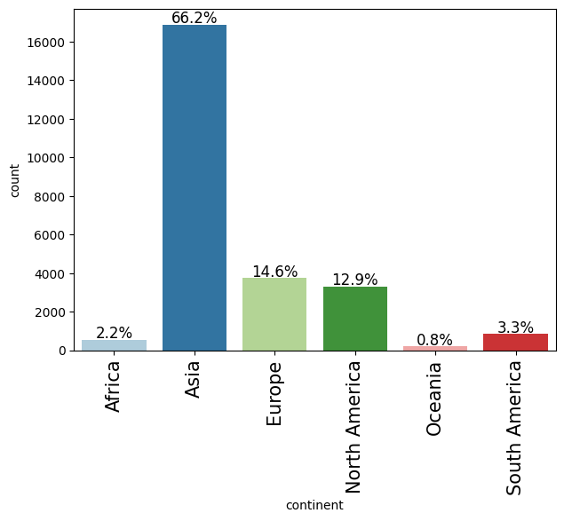

```python
labeled_barplot(data, "continent", perc=True)
```

- Asia dominates — nearly two-thirds of all visa applicants come from Asia, making it by far the largest group
- Europe and North America are a distant second and third, each accounting for roughly 13–15%
- South America, Africa, and Oceania together make up only ~6% of applicants — these categories are significantly underrepresented
- The distribution is highly imbalanced across continents; any model using this feature should account for the class imbalance, particularly for minority continents like Oceania

### Observations on education of employee

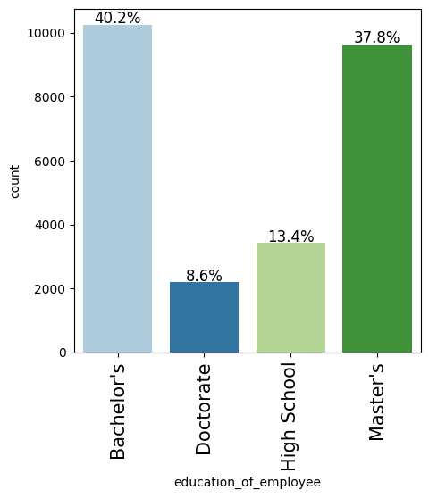

```python
labeled_barplot(data, "education_of_employee", perc=True)
```

- Bachelor's degree holders make up the largest group (~40%), followed by Master's (~38%), High School (~13%), and Doctorate (~9%).
- The majority of applicants have at least a Bachelor's degree (~86% combined)
- Higher education level is strongly associated with higher visa approval rates:  
  -- Doctorate: 87.2% certified  
  -- Master's: 78.6% certified  
  -- Bachelor's: 62.2% certified  
  -- High School: only 34% certified — more likely to be denied than approved
- High School applicants are the only education group where denial is the more likely outcome
- There is a clear positive relationship between education level and visa certification rate

### Observations on job experience

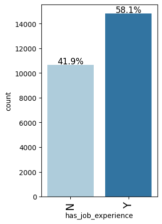

```python
labeled_barplot(data, "has_job_experience", perc=True)
```

- The majority of applicants (~58%) have prior job experience, while ~42% do not
- Applicants with job experience have a notably higher visa certification rate at 74.5% vs 56.1% for those without
- Applicants without job experience are more evenly split between certified and denied, suggesting experience is a meaningful differentiator
- Having job experience nearly halves the likelihood of denial (25.5% vs 43.9%)
- Job experience appears to be one of the stronger indicators of visa approval in this dataset

### Observations on requires job training

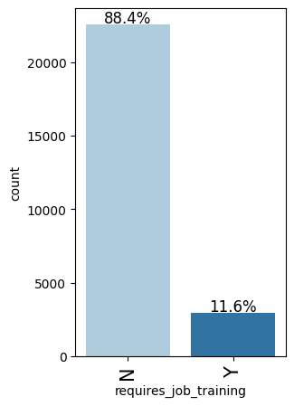

```python
labeled_barplot(data, "requires_job_training", perc=True)
```

- Most applications do not require training

### Observations on no_of_employees

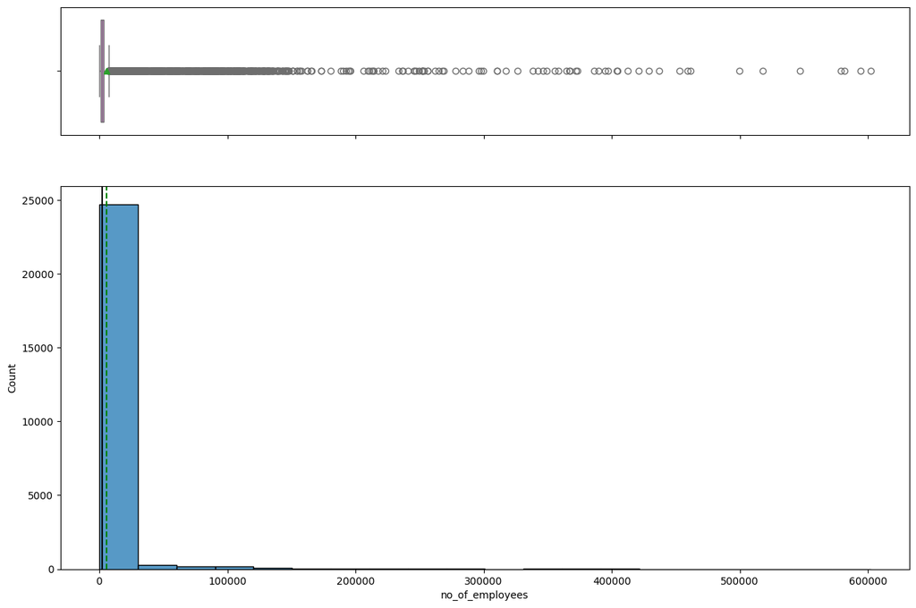

```python
histogram_boxplot(data, 'no_of_employees', bins = 20)
```

- The distribution of company size is highly right-skewed, with a mean of ~5,667 employees but a median of only 2,109, indicating most applicants come from mid-sized companies
- The vast majority of applicants (~77%) work for companies with 501–5,000 employees
- 33 records contained negative employee counts, treated as data entry errors and corrected by taking absolute values
- Larger companies show a modest positive relationship with visa certification rate — companies with 5,001–25,000 employees have the highest approval rate at 70.8%
- Smaller companies (1–500 employees) have a lower certification rate of 65.1%
- The wide standard deviation (~22,877) and a maximum of 602,069 indicate significant outliers on the high end that will need to be addressed in pre-processing

### Observations on yr_of_estab

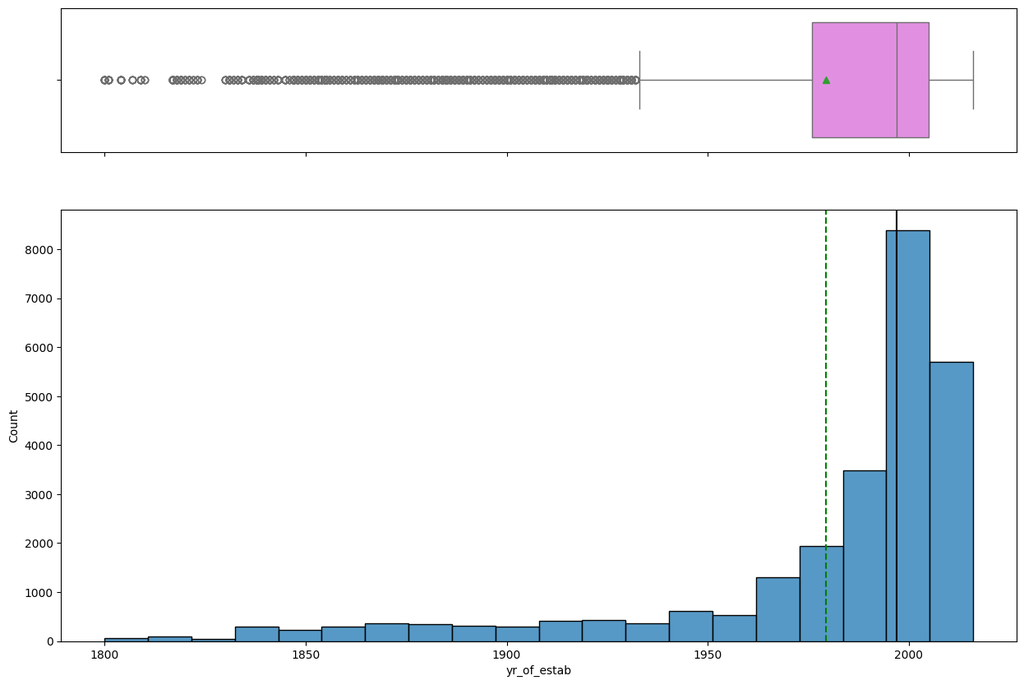

```python
histogram_boxplot(data, 'yr_of_estab', bins = 20)
```

- Year of establishment ranges from 1800 to 2016, with a median of 1997, meaning half of all applicant companies were established in the last ~25 years of the dataset
- The distribution is left-skewed (skewness = -2.04), with a long tail of older companies pulling the mean (1979) well below the median
- Companies established between 2000–2010 represent the largest group (~31% of applicants), followed by those established 1990–2000 (~23%)

### Observations on region of employment

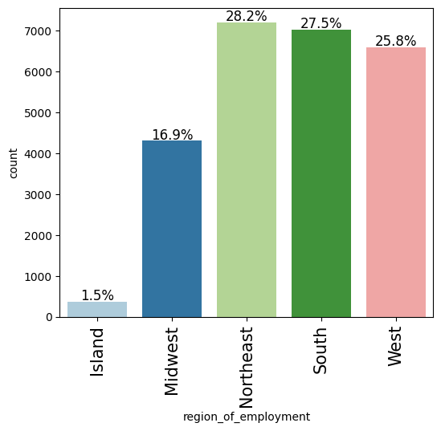

```python
labeled_barplot(data, "region_of_employment", perc=True)
```

- Northeast is the most common region of employment (~28%), followed closely by South (~28%) and West (~26%), with Midwest (~17%) and Island (~1.5%) trailing
- Northeast, South, and West together account for over 81% of all visa applications
- Island region has the fewest applications by far, making up only 1.5% of cases
- Midwest has the highest visa certification rate at 75.5%, notably higher than other regions
- South has the second highest certification rate at 70%
- Northeast, West, and Island have similar and lower certification rates (~60–63%), with denial being more common relative to Midwest and South
- There is moderate variation in approval rates across regions, suggesting region of employment is a relevant factor in visa outcomes

### Observations on prevailing_wage

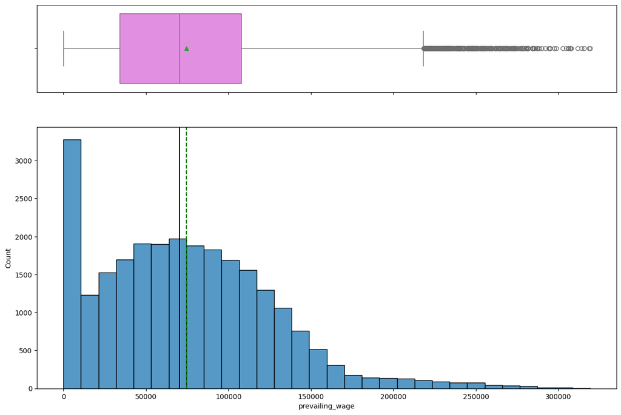

```python
histogram_boxplot(data, "prevailing_wage", bins=30)
```

- The distribution of prevailing wage is right-skewed, with a mean (~$74,456) pulled above the median (~$70,308) by a long upper tail of high-wage positions
- The middle 50% of wages fall between ~$34,015 and ~$107,736, indicating most applicants are in a broad but reasonable mid-range
- The extreme range — from $2.14 to $319,210 — reflects the mix of hourly and yearly wage units still present in the raw column, which exaggerates the spread
- Numerous high-value outliers are visible in the boxplot, consistent with a small number of very high-paying specialized roles

### Observations on Unit of Wage

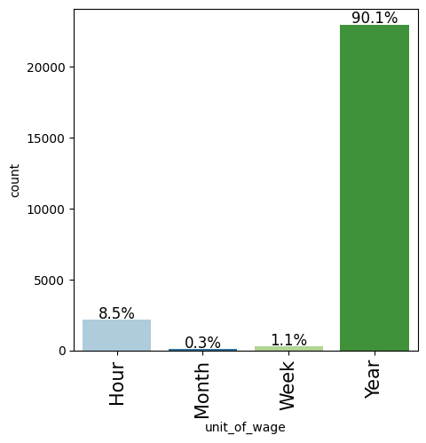

```python
labeled_barplot(data, "unit_of_wage", perc=True)
```

- The vast majority of positions (~90%) report wages on a yearly basis, making it the dominant unit by far
- Hourly positions account for ~8.5% of applications — a distant second
- Weekly (~1%) and Monthly (~0.3%) are rare edge cases with minimal representation
- The heavy skew toward yearly wages explains much of the spread seen in prevailing_wage — mixing hourly rates like $2.14 with annual salaries of $319,210 in the same column inflates variance artificially
- Because yearly dominates so heavily, unit_of_wage is low-variance as a standalone feature but carries important context for interpreting prevailing_wage values

### Observations on full_time_position

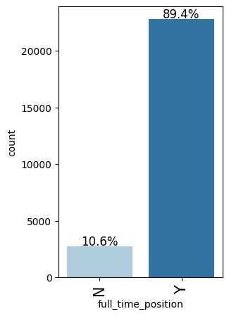

```python
labeled_barplot(data, "full_time_position", perc=True)
```

- The vast majority of visa applications (~89%) are for full-time positions, with only ~11% for part-time roles
- The distribution is heavily imbalanced between full-time and part-time positions

### Observations on case status

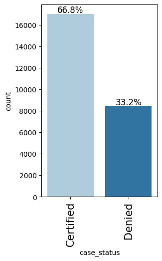

```python
labeled_barplot(data, "case_status", perc=True)
```

- 66.8% of the visas were certified.
- The target variable is moderately imbalanced — certified cases are roughly twice as common as denied cases, which may need to be addressed before modeling

## Bivariate Analysis

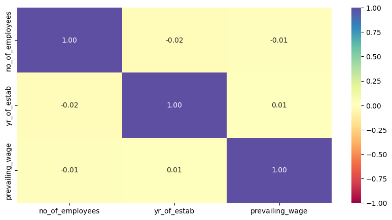

```python
cols_list = data.select_dtypes(include=np.number).columns.tolist()

plt.figure(figsize=(10, 5))
sns.heatmap(
    data[cols_list].corr(), annot=True, vmin=-1, vmax=1, fmt=".2f", cmap="Spectral"
)
plt.show()
```

```python
### functions

def distribution_plot_wrt_target(data, predictor, target):

    fig, axs = plt.subplots(2, 2, figsize=(12, 10))

    target_uniq = data[target].unique()

    axs[0, 0].set_title("Distribution of target for target=" + str(target_uniq[0]))
    sns.histplot(
        data=data[data[target] == target_uniq[0]],
        x=predictor,
        kde=True,
        ax=axs[0, 0],
        color="teal",
        stat="density",
    )

    axs[0, 1].set_title("Distribution of target for target=" + str(target_uniq[1]))
    sns.histplot(
        data=data[data[target] == target_uniq[1]],
        x=predictor,
        kde=True,
        ax=axs[0, 1],
        color="orange",
        stat="density",
    )

    axs[1, 0].set_title("Boxplot w.r.t target")
    sns.boxplot(data=data, x=target, y=predictor, ax=axs[1, 0], palette="gist_rainbow")

    axs[1, 1].set_title("Boxplot (without outliers) w.r.t target")
    sns.boxplot(
        data=data,
        x=target,
        y=predictor,
        ax=axs[1, 1],
        showfliers=False,
        palette="gist_rainbow",
    )

    plt.tight_layout()
    plt.show()
```

```python
def stacked_barplot(data, predictor, target):
    """
    Print the category counts and plot a stacked bar chart

    data: dataframe
    predictor: independent variable
    target: target variable
    """
    count = data[predictor].nunique()
    sorter = data[target].value_counts().index[-1]
    tab1 = pd.crosstab(data[predictor], data[target], margins=True).sort_values(
        by=sorter, ascending=False
    )
    print(tab1)
    print("-" * 120)
    tab = pd.crosstab(data[predictor], data[target], normalize="index").sort_values(
        by=sorter, ascending=False
    )
    tab.plot(kind="bar", stacked=True, figsize=(count + 5, 5))
    plt.legend(
        loc="lower left", frameon=False,
    )
    plt.legend(loc="upper left", bbox_to_anchor=(1, 1))
    plt.show()
```

#### Continent vs visa certification

```
case_status    Certified  Denied    All
continent
All                17018    8462  25480
Asia               11012    5849  16861
North America       2037    1255   3292
Europe              2957     775   3732
South America        493     359    852
Africa               397     154    551
Oceania              122      70    192
------------------------------------------------------------------------------------------------------------------------
```

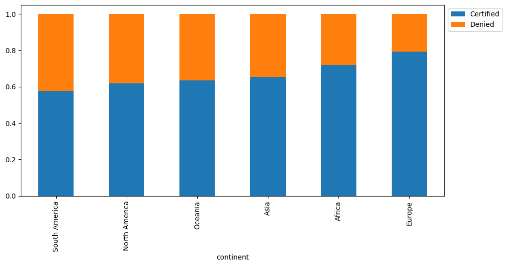

```python
stacked_barplot(data, "continent", "case_status")
```

- Across all continents, Certified is the dominant outcome — no continent's bar is majority Denied
- The variation in the certified proportion across continent bars suggests continent has some relationship with case outcome and may be worth including as a feature in the model

#### Education vs visa certification

```
case_status            Certified  Denied    All
education_of_employee
All                        17018    8462  25480
Bachelor's                  6367    3867  10234
High School                 1164    2256   3420
Master's                    7575    2059   9634
Doctorate                   1912     280   2192
------------------------------------------------------------------------------------------------------------------------
```

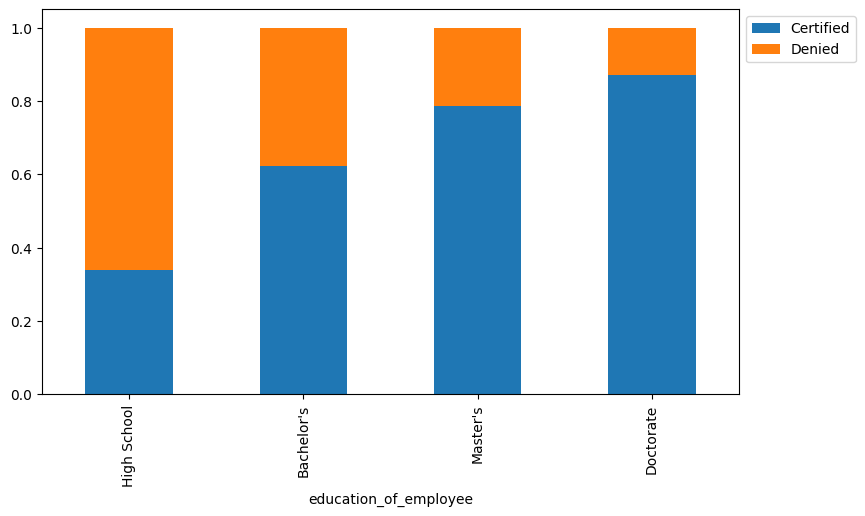

```python
stacked_barplot(data, "education_of_employee", "case_status")
```

- There is a clear positive relationship between education level and visa certification rate — higher education strongly predicts approval

#### Work Experience vs visa certification

```
case_status         Certified  Denied    All
has_job_experience
All                     17018    8462  25480
N                        5994    4684  10678
Y                       11024    3778  14802
------------------------------------------------------------------------------------------------------------------------
```

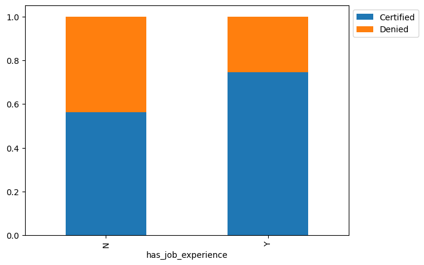

```python
stacked_barplot(data, "has_job_experience", "case_status")
```

- Applicants with job experience (Y) have a visibly larger certified portion in their bar — approximately ~74% certified vs. ~26% denied
- Applicants without job experience (N) show a much more balanced split — approximately ~56% certified vs. ~44% denied, with the denied portion noticeably larger compared to the Y bar
- The difference in certified proportion between the two bars is substantial, making the split between Y and N clearly visible in the stacked plot
- Having job experience appears to be a strong positive signal for visa certification
- This suggests has_job_experience is likely to be an important predictive feature in the model

### Requires job training and case_status

```
case_status            Certified  Denied    All
requires_job_training
All                        17018    8462  25480
N                          15012    7513  22525
Y                           2006     949   2955
------------------------------------------------------------------------------------------------------------------------
```

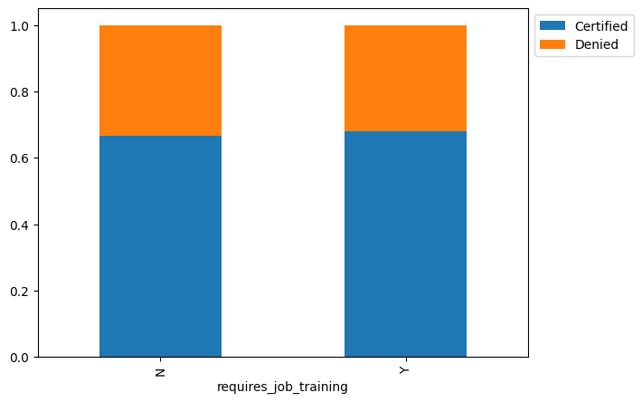

```python
stacked_barplot(data, "requires_job_training", "case_status")
```

### No. employees and case_status

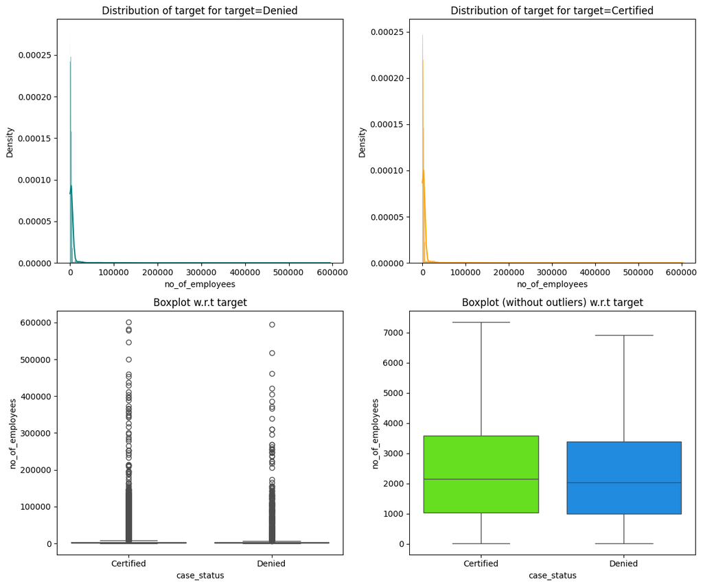

```python
distribution_plot_wrt_target(data, "no_of_employees", "case_status")
```

- Both Certified and Denied distributions are extremely right-skewed — the vast majority of employers have relatively small employee counts, with a very long tail of large companies
- This suggests no_of_employees on its own is a weak predictor of case status — the distributions do not meaningfully differ by outcome
- The extreme outlier range (up to 602,069) and noted negative values (corrected via .abs()) indicate this feature needs outlier treatment (e.g. capping at 99th percentile) before modeling

### Year of establishment and case_status

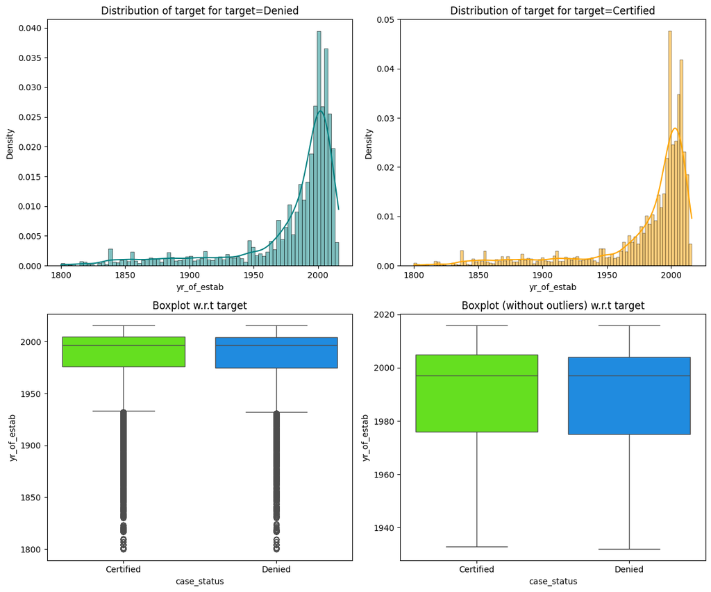

```python
distribution_plot_wrt_target(data, "yr_of_estab", "case_status")
```

- The left-skew and extreme low outliers suggest yr_of_estab may benefit from being engineered into company age (subtracting from a reference year) to make it more interpretable and linear — consistent with the notebook's feature engineering plan
- Overall, yr_of_estab appears to be a weak direct predictor of case status on its own, though company age may carry more signal once transformed

### Region of employement vs case status

```
case_status           Certified  Denied    All
region_of_employment
All                       17018    8462  25480
Northeast                  4526    2669   7195
West                       4100    2486   6586
South                      4913    2104   7017
Midwest                    3253    1054   4307
Island                      226     149    375
------------------------------------------------------------------------------------------------------------------------
```

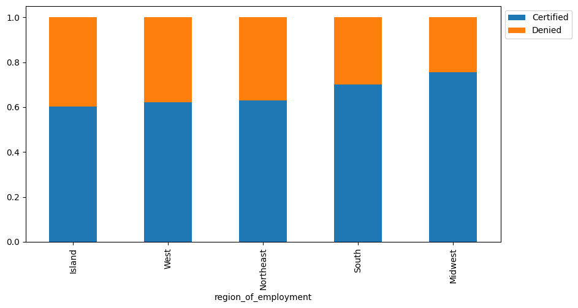

```python
stacked_barplot(data, "region_of_employment", "case_status")
```

- Northeast, South, and West are the three dominant employment regions, each with broadly similar application volumes (~26–28% each)
- Midwest has a noticeably higher visa certification rate (~75.5%) compared to other regions, making it the most favorable region for approval
- South has the second highest certification rate (~70%), also above the overall dataset average of ~67%
- Northeast, West, and Island cluster at lower certification rates (~60–63%), where denial is relatively more common compared to Midwest and South
- Island has the fewest applications (~1.5%) and a lower certification rate, though its small sample size limits the reliability of that estimate
- The variation in approval rates across regions suggests region_of_employment carries meaningful predictive signal for the model

### Prevailing Wage across regions

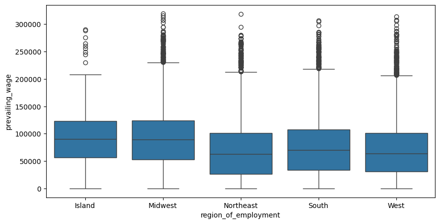

```python
plt.figure(figsize=(10, 5))
sns.boxplot(data=data, x="region_of_employment", y="prevailing_wage")
plt.show()
```

### Prevailing Wage vs case status

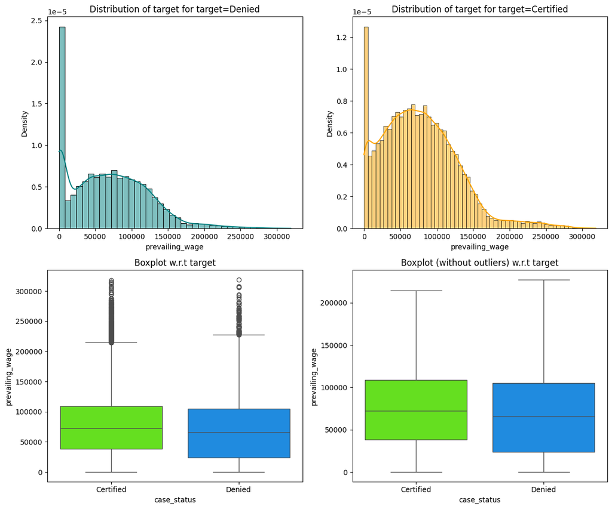

```python
distribution_plot_wrt_target(data, "prevailing_wage", "case_status")
```

- Both Certified and Denied distributions are heavily right-skewed, with long tails stretching toward very high wage values — consistent with what the boxplot already showed.
- The boxplot portion of the figure likely shows the Certified median wage is higher than the Denied median, with both groups having substantial outliers on the high end
- The heavy right skew in both groups reinforces that prevailing_wage should likely be log-transformed before use in a model to avoid the extreme values dominating

### Unit of wage and case status

```
case_status   Certified  Denied    All
unit_of_wage
All               17018    8462  25480
Year              16047    6915  22962
Hour                747    1410   2157
Week                169     103    272
Month                55      34     89
------------------------------------------------------------------------------------------------------------------------
```

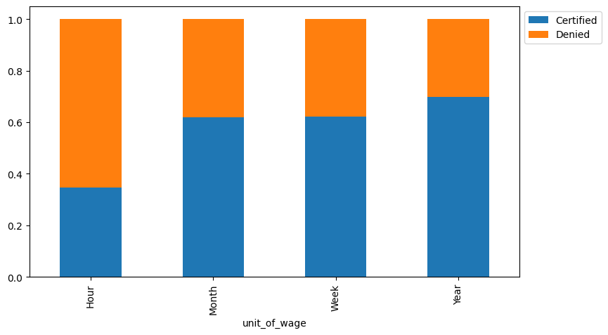

```python
stacked_barplot(data, "unit_of_wage", "case_status")
```

### Full time status vs case_status

```
case_status         Certified  Denied    All
full_time_position
All                     17018    8462  25480
Y                       15163    7610  22773
N                        1855     852   2707
------------------------------------------------------------------------------------------------------------------------
```

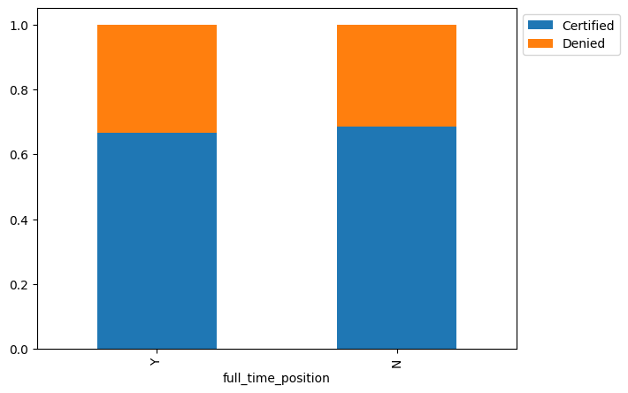

```python
stacked_barplot(data, "full_time_position", "case_status")
```

# **Data Pre-processing**

1. Confirmed no missing values
2. Confirmed no duplicate rows
3. Fixed negative values in no_of_employees (abs())
4. Feature engineering — company_age, high_skill, strong_candidate
5. Encode case_status (Certified → 1, Denied → 0) and one-hot encode categorical features
6. Train / validation / test split (60/20/20, stratified)
7. Cap no_of_employees at 99th percentile (train only), apply to val and test
8. Bin no_of_employees into meaningful buckets, one-hot encode, drop original
9. Cap prevailing_wage at 99th percentile (train only), apply to val and test

### Outlier Check

- Let's check for outliers in the data.

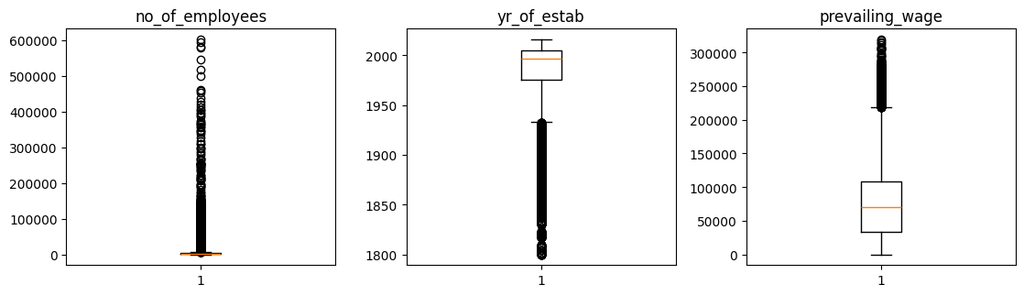

```python
# outlier detection using boxplot
numeric_columns = data.select_dtypes(include=np.number).columns.tolist()


plt.figure(figsize=(15, 12))

for i, variable in enumerate(numeric_columns):
    plt.subplot(4, 4, i + 1)
    plt.boxplot(data[variable], whis=1.5)
    plt.tight_layout()
    plt.title(variable)

plt.show()
```

### Feature engineering

#### Company Age

```python
## Engineer company age from yr_of_estab, drop yr_of_estab
data["company_age"] = 2024 - data["yr_of_estab"]
data.drop("yr_of_estab", axis=1, inplace=True)
```

#### Prevailing Wage note.

prevailing_wage is retained in its original unit without normalization. Since the exact working hours and days vary by position, any conversion would introduce assumptions that may distort the values. Additionally, unit_of_wage is itself a meaningful predictor (hourly positions have significantly lower certification rates), and tree-based models can jointly exploit both columns without requiring them to be merged. Dropping unit_of_wage after conversion would discard this signal.

#### High skill flag.

We are creating a binary column, called high_skill, where education_of_employee is Master's or Doctorate since EDA showed a sharp approval cliff here

```python
### create high_skill flaf based on education_of_employee column
data["high_skill"] = data["education_of_employee"].apply(
    lambda x: 1
    if x in [
        "Doctorate",
        "Master's",
    ]
    else 0
)
```

```
case_status  Certified  Denied    All
high_skill
All              17018    8462  25480
0                 7531    6123  13654
1                 9487    2339  11826
------------------------------------------------------------------------------------------------------------------------
```

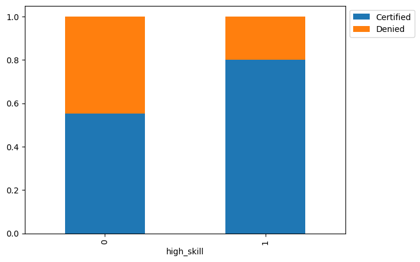

```python
stacked_barplot(data, "high_skill", "case_status")
```

#### Strong Candidate flag

```python
### create strong_candidate flag based on has_job_experience and education_of_employee columns
data["strong_candidate"] = data.apply(
    lambda x: 1
    if (x["has_job_experience"] == "Y")
    and (x["education_of_employee"] in ["Doctorate", "Master's"])
    else 0,
    axis=1,
)
```

```
case_status       Certified  Denied    All
strong_candidate
All                   17018    8462  25480
0                     10852    7736  18588
1                      6166     726   6892
------------------------------------------------------------------------------------------------------------------------
```

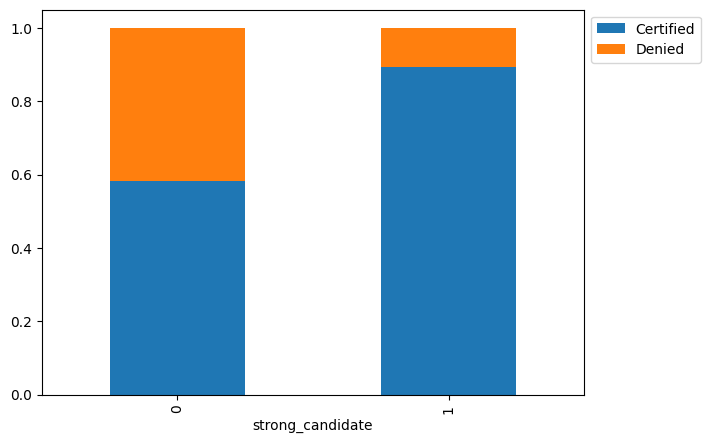

```python
stacked_barplot(data, "strong_candidate", "case_status")
```

## Train/Test split

```python
data["case_status"] = data["case_status"].map({"Certified": 1, "Denied": 0})

X = data.drop(["case_status"], axis=1)
y = data["case_status"]

# 1. Split FIRST (before any encoding)
X_temp, X_test, y_temp, y_test = train_test_split(X, y, test_size=0.2, random_state=1, stratify=y)
X_train, X_val, y_train, y_val = train_test_split(X_temp, y_temp, test_size=0.25, random_state=1, stratify=y_temp)

# 2. Fit encoding on train only, then align val/test to same columns
X_train = pd.get_dummies(X_train, drop_first=True)
X_val   = pd.get_dummies(X_val,   drop_first=True).reindex(columns=X_train.columns, fill_value=0)
X_test  = pd.get_dummies(X_test,  drop_first=True).reindex(columns=X_train.columns, fill_value=0)
```

### cap no_of_employees outliers.

Why cap on train only

The 99th percentile cap value is a statistic derived from the data. If we compute it on the full dataset, the test set influences the threshold — that's data leakage. Computing it on train only means the test set is treated as truly unseen data.

```python
## We treat outliers in no_of_employees — compute 99th percentile cap on **train only**, apply clip to both train and test
cap = X_train["no_of_employees"].quantile(0.99)
X_train["no_of_employees"] = X_train["no_of_employees"].clip(upper=cap)
X_val["no_of_employees"] = X_val["no_of_employees"].clip(upper=cap)
X_test["no_of_employees"] = X_test["no_of_employees"].clip(upper=cap)
```

- checking the distribution on each

```python
print("Before cap max:", 602069)
print("After cap max:", X_train["no_of_employees"].max())
```

```
Before cap max: 602069
After cap max: 102775.0499999997
```

#### binning no_of_employees

We are still going to put these in more meaningful bins givin the distribution

```
case_status               1     0    All
no_of_employees_bins
All                   10210  5078  15288
1001-5000              6613  3360   9973
501-1000               1289   634   1923
201-500                 755   347   1102
51-200                  352   206    558
5001-10000              520   199    719
10001-50000             341   160    501
50000+                  245   107    352
0-50                     95    65    160
------------------------------------------------------------------------------------------------------------------------
```

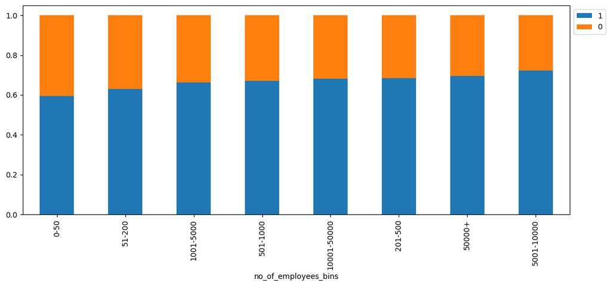

```python
bins = [-1, 50, 200, 500, 1000, 5000, 10000, 50000, np.inf]
labels = ["0-50", "51-200", "201-500", "501-1000", "1001-5000", "5001-10000", "10001-50000", "50000+"]

X_train["no_of_employees_bins"] = pd.cut(X_train["no_of_employees"], bins=bins, labels=labels)
X_val["no_of_employees_bins"]   = pd.cut(X_val["no_of_employees"],   bins=bins, labels=labels)
X_test["no_of_employees_bins"]  = pd.cut(X_test["no_of_employees"],  bins=bins, labels=labels)

##stacked_barplot needs both columns in the same dataframe. Temporarily combine X_train and y_train:


train_plot = X_train.copy()
train_plot["case_status"] = y_train.values

stacked_barplot(train_plot, "no_of_employees_bins", "case_status")
```

```python
## encode these new bins and drop the original no_of_employees column
X_train = pd.get_dummies(X_train, columns=["no_of_employees_bins"], drop_first=True)
X_val = pd.get_dummies(X_val, columns=["no_of_employees_bins"], drop_first=True)
X_test = pd.get_dummies(X_test, columns=["no_of_employees_bins"], drop_first=True)

## drop the original no_of_employees column
X_train.drop("no_of_employees", axis=1, inplace=True)
X_val.drop("no_of_employees", axis=1, inplace=True)
X_test.drop("no_of_employees", axis=1, inplace=True)
```

### capping prevailing_wage.

Like the no_of_employees, we cap this after the train/test split to avoid leakage

```python
## We treat outliers in prevailing_wage — compute 99th percentile cap on **train only**, apply clip to both train and test
cap = X_train["prevailing_wage"].quantile(0.99)
X_train["prevailing_wage"] = X_train["prevailing_wage"].clip(upper=cap)
X_val["prevailing_wage"] = X_val["prevailing_wage"].clip(upper=cap)
X_test["prevailing_wage"] = X_test["prevailing_wage"].clip(upper=cap)
```

```python
print("Shape of Training set : ", X_train.shape)
print("Shape of the Validation set: ", X_val.shape)
print("Shape of test set : ", X_test.shape)
print("Percentage of classes in training set:")
print(y_train.value_counts(normalize=True))
print("Percentage of classes in validation set:")
print(y_val.value_counts(normalize=True))
print("Percentage of classes in test set:")
print(y_test.value_counts(normalize=True))
```

```
Shape of Training set :  (15288, 29)
Shape of the Validation set:  (5096, 29)
Shape of test set :  (5096, 29)
Percentage of classes in training set:
case_status
1    0.667844
0    0.332156
Name: proportion, dtype: float64
Percentage of classes in validation set:
case_status
1    0.667975
0    0.332025
Name: proportion, dtype: float64
Percentage of classes in test set:
case_status
1    0.667975
0    0.332025
Name: proportion, dtype: float64
```

# **Model Building**

### Functions for reuse

```python
# defining a function to compute different metrics to check performance of a classification model built using sklearn
# The model_performance_classification_sklearn function will be used to check the model performance of models.

def model_performance_classification_sklearn(model, predictors, target):
    """
    Function to compute different metrics to check classification model performance

    model: classifier
    predictors: independent variables
    target: dependent variable
    """

    # predicting using the independent variables
    pred = model.predict(predictors)

    acc = accuracy_score(target, pred)  # to compute Accuracy
    recall = recall_score(target, pred)  # to compute Recall
    precision = precision_score(target, pred)  # to compute Precision
    f1 = f1_score(target, pred)  # to compute F1-score

    # creating a dataframe of metrics
    df_perf = pd.DataFrame(
        {"Accuracy": acc, "Recall": recall, "Precision": precision, "F1": f1,},
        index=[0],
    )

    return df_perf
```

```python
# defining a function to plot the confusion_matrix with percentages
# The confusion_matrix_sklearn function will be used to plot the confusion matrix with percentages.

def confusion_matrix_sklearn(model, predictors, target):
    """
    To plot the confusion_matrix with percentages

    model: classifier
    predictors: independent variables
    target: dependent variable
    """
    y_pred = model.predict(predictors)
    cm = confusion_matrix(target, y_pred)
    labels = np.asarray(
        [
            ["{0:0.0f}".format(item) + "\n{0:.2%}".format(item / cm.flatten().sum())]
            for item in cm.flatten()
        ]
    ).reshape(2, 2)

    plt.figure(figsize=(6, 4))
    sns.heatmap(cm, annot=labels, fmt="")
    plt.ylabel("True label")
    plt.xlabel("Predicted label")
```

## Model Building - Original Data

```python
models = []  # Empty list to store all the models

# Appending models into the list
models.append(("Bagging", BaggingClassifier(random_state=1)))
models.append(("Random Forest", RandomForestClassifier(random_state=1, class_weight="balanced")))
models.append(("AdaBoost", AdaBoostClassifier(random_state=1)))
models.append(("Gradient Boosting", GradientBoostingClassifier(random_state=1)))
models.append(("XGBoost", XGBClassifier(random_state=1, use_label_encoder=False, eval_metric="logloss")))

print("\n" "Training Performance:" "\n")
for name, model in models:
    model.fit(X_train, y_train)
    scores = f1_score(y_train, model.predict(X_train))
    print("{}: {}".format(name, scores))

print("\n" "Validation Performance:" "\n")

for name, model in models:
    model.fit(X_train, y_train)
    scores_val = f1_score(y_val, model.predict(X_val))
    print("{}: {}".format(name, scores_val))
```

```
Training Performance:

Bagging: 0.9884029484029484
Random Forest: 1.0
AdaBoost: 0.822153024911032
Gradient Boosting: 0.827741935483871
XGBoost: 0.8836732793145199

Validation Performance:

Bagging: 0.7771546635182999
Random Forest: 0.797896532120523
AdaBoost: 0.8211088844355378
Gradient Boosting: 0.8274139844617092
XGBoost: 0.8118452297806956
```

- Bagging and Random Forest are heavily overfitting — near-perfect training scores (0.988, 1.0) but much lower validation scores, indicating they've memorized the training data
- AdaBoost and Gradient Boosting generalize best — the train/val gap is negligible, suggesting these are the most stable models on original data
- Gradient Boosting has the highest validation F1 (0.827), making it the strongest performer at this stage
- All models use default hyperparameters — tuning is likely to improve results, especially for the overfitting models
- The validation F1 range (~0.777–0.827) leaves room for improvement through hyperparameter tuning and/or resampling

## Model Building - Oversampled Data

```python
print("Before Oversampling, counts of label 'Certified': {}".format(sum(y_train == 1)))
print("Before Oversampling, counts of label 'Denied': {} \n".format(sum(y_train == 0)))

sm = SMOTE(
    sampling_strategy=1, k_neighbors=5, random_state=1
)  # Synthetic Minority Over Sampling Technique
X_train_over, y_train_over = sm.fit_resample(X_train, y_train)


print("After Oversampling, counts of label 'Certified': {}".format(sum(y_train_over == 1)))
print("After Oversampling, counts of label 'Denied': {} \n".format(sum(y_train_over == 0)))


print("After Oversampling, the shape of train_X: {}".format(X_train_over.shape))
print("After Oversampling, the shape of train_y: {} \n".format(y_train_over.shape))
```

```
Before Oversampling, counts of label 'Certified': 10210
Before Oversampling, counts of label 'Denied': 5078

After Oversampling, counts of label 'Certified': 10210
After Oversampling, counts of label 'Denied': 10210

After Oversampling, the shape of train_X: (20420, 29)
After Oversampling, the shape of train_y: (20420,)
```

```python
models = []  # Empty list to store all the models

# Appending models into the list
models.append(("Bagging", BaggingClassifier(random_state=1)))
models.append(("Random Forest", RandomForestClassifier(random_state=1, class_weight="balanced")))
models.append(("AdaBoost", AdaBoostClassifier(random_state=1)))
models.append(("Gradient Boosting", GradientBoostingClassifier(random_state=1)))
models.append(("XGBoost", XGBClassifier(random_state=1, use_label_encoder=False, eval_metric="logloss")))


print("\n" "Training Performance:" "\n")
for name, model in models:
    model.fit(X_train_over, y_train_over)
    scores = f1_score(y_train_over, model.predict(X_train_over))
    print("{}: {}".format(name, scores))

print("\n" "Validation Performance:" "\n")

for name, model in models:
    model.fit(X_train_over, y_train_over)
    scores = f1_score(y_val, model.predict(X_val))
    print("{}: {}".format(name, scores))
```

```
Training Performance:

Bagging: 0.9863256271519921
Random Forest: 0.9999020472132432
AdaBoost: 0.7825503998467653
Gradient Boosting: 0.819290414615066
XGBoost: 0.8681486981946442

Validation Performance:

Bagging: 0.7670539171879655
Random Forest: 0.7893749097733507
AdaBoost: 0.7892142650043491
Gradient Boosting: 0.8229398663697105
XGBoost: 0.8154770219304373
```

- SMOTE balanced the training set — Denied class grew from 5,078 to 10,210, matching Certified exactly (1:1 ratio), doubling the training set to 20,420 rows
- Bagging and Random Forest still overfit heavily — SMOTE did not resolve their train/val gap, suggesting the issue is model capacity not class imbalance
- Gradient Boosting again leads validation F1 (0.823), nearly matching its original data performance (0.827) — very stable across both datasets
- XGBoost improved slightly with oversampling (0.812 → 0.815), suggesting it benefits modestly from balanced classes
- AdaBoost declined with oversampling (0.821 → 0.789) — it was already generalizing well on original data and SMOTE introduced noise
- Overall, oversampling did not meaningfully improve any model — the 67/33 imbalance is mild enough that SMOTE adds noise rather than signal

## Model Building - Undersampled Data

```python
rus = RandomUnderSampler(random_state=1)
X_train_un, y_train_un = rus.fit_resample(X_train, y_train)
```

```python
print("Before Under Sampling, counts of label 'Certified': {}".format(sum(y_train == 1)))
print("Before Under Sampling, counts of label 'Denied': {} \n".format(sum(y_train == 0)))

print("After Under Sampling, counts of label 'Certified': {}".format(sum(y_train_un == 1)))
print("After Under Sampling, counts of label 'Denied': {} \n".format(sum(y_train_un == 0)))

print("After Under Sampling, the shape of train_X: {}".format(X_train_un.shape))
print("After Under Sampling, the shape of train_y: {} \n".format(y_train_un.shape))
```

```
Before Under Sampling, counts of label 'Certified': 10210
Before Under Sampling, counts of label 'Denied': 5078

After Under Sampling, counts of label 'Certified': 5078
After Under Sampling, counts of label 'Denied': 5078

After Under Sampling, the shape of train_X: (10156, 29)
After Under Sampling, the shape of train_y: (10156,)
```

```python
models = []  # Empty list to store all the models

# Appending models into the list
models.append(("Bagging", BaggingClassifier(random_state=1)))
models.append(("Random Forest", RandomForestClassifier(random_state=1, class_weight="balanced")))
models.append(("AdaBoost", AdaBoostClassifier(random_state=1)))
models.append(("Gradient Boosting", GradientBoostingClassifier(random_state=1)))
models.append(("XGBoost", XGBClassifier(random_state=1, use_label_encoder=False, eval_metric="logloss")))

print("\nTraining Performance:\n")
for name, model in models:
    model.fit(X_train_un, y_train_un)
    scores = f1_score(y_train_un, model.predict(X_train_un))
    print("{}: {}".format(name, scores))

print("\nValidation Performance:\n")
for name, model in models:
    model.fit(X_train_un, y_train_un)
    scores_val = f1_score(y_val, model.predict(X_val))
    print("{}: {}".format(name, scores_val))
```

```
Training Performance:

Bagging: 0.9793598564163924
Random Forest: 1.0
AdaBoost: 0.6814204837879567
Gradient Boosting: 0.726675680896272
XGBoost: 0.8527481140393848

Validation Performance:

Bagging: 0.7075218267293486
Random Forest: 0.7377605428986912
AdaBoost: 0.7341645885286783
Gradient Boosting: 0.7738788355625492
XGBoost: 0.7423538831064852
```

- RandomUnderSampler discarded 5,132 Certified examples to achieve a 1:1 balance (5,078 each class), shrinking the training set from 15,288 to 10,156 rows
- Undersampling is the worst strategy overall — every model's validation F1 dropped compared to original data (Gradient Boosting: 0.827 → 0.774, XGBoost: 0.812 → 0.742), confirming that discarding real training data hurts more than the mild 67/33 imbalance warrants
- Gradient Boosting still leads at validation F1 0.774, remaining the most stable model across all three sampling strategies
- Bagging and Random Forest continue to overfit severely (train 0.979/1.0 vs val 0.708/0.738) — the root cause is model capacity, not class imbalance, so undersampling does not fix it
- AdaBoost's training score collapsed to 0.681 — it performs well with boosting on larger datasets but struggles when the training set is halved
- Gradient Boosting's small train/val gap (0.727 vs 0.774) makes it the only model that generalizes cleanly even on undersampled data

## Model Building Summary

- Across all three sampling strategies, **Gradient Boosting consistently delivered the best validation F1 score**.
- Training on the **original data** yielded the strongest results (F1 ≈ 0.827).
- **SMOTE oversampling** provided no meaningful improvement (F1 ≈ 0.823).
- **Undersampling** hurt performance across all models (F1 ≈ 0.774), likely because discarding majority-class training data reduced the information available to the models.
- Given these results, the original data with Gradient Boosting is the most promising baseline to carry forward for tuning.

# **Model Performance Improvement**

## **Data Selection**

The original dataset was selected for all hyperparameter tuning across every model in this section. Baseline evaluation across Random Forest, AdaBoost, Gradient Boosting, and XGBoost consistently showed that original data produced the highest or matched validation F1 scores. SMOTE oversampling introduced synthetic noise with no meaningful gain, and undersampling discarded real training examples, reducing performance. Using original data for tuning ensures improvements reflect genuine generalization rather than artifacts of resampling.

## **Note**

1. Sample parameter grids have been provided to do necessary hyperparameter tuning. These sample grids are expected to provide a balance between model performance improvement and execution time. One can extend/reduce the parameter grid based on execution time and system configuration.
- Please note that if the parameter grid is extended to improve the model performance further, the execution time will increase
2. The models chosen in this notebook are based on test runs. One can update the best models as obtained upon code execution and tune them for best performance.
- For Gradient Boosting:

```
param_grid = {
    "init": [AdaBoostClassifier(random_state=1),DecisionTreeClassifier(random_state=1)],
    "n_estimators": np.arange(50,110,25),
    "learning_rate": [0.01,0.1,0.05],
    "subsample":[0.7,0.9],
    "max_features":[0.5,0.7,1],
}
```

- For Adaboost:

```
param_grid = {
    "n_estimators": np.arange(50,110,25),
    "learning_rate": [0.01,0.1,0.05],
    "base_estimator": [
        DecisionTreeClassifier(max_depth=2, random_state=1),
        DecisionTreeClassifier(max_depth=3, random_state=1),
    ],
}
```

- For Bagging Classifier:

```
param_grid = {
    'max_samples': [0.8,0.9,1],
    'max_features': [0.7,0.8,0.9],
    'n_estimators' : [30,50,70],
}
```

- For Random Forest:

```
param_grid = {
    "n_estimators": [50,110,25],
    "min_samples_leaf": np.arange(1, 4),
    "max_features": [*np.arange(0.3, 0.6, 0.1), 'sqrt'],
    "max_samples": np.arange(0.4, 0.7, 0.1)
}
```

- For Decision Trees:

```
param_grid = {
    'max_depth': np.arange(2,6),
    'min_samples_leaf': [1, 4, 7],
    'max_leaf_nodes' : [10, 15],
    'min_impurity_decrease': [0.0001,0.001]
}
```

- For XGBoost:

```
param_grid={'n_estimators':np.arange(50,110,25),
            'scale_pos_weight':[1,2,5],
            'learning_rate':[0.01,0.1,0.05],
            'gamma':[1,3],
            'subsample':[0.7,0.9]
}
```

# Tuning

- hyperparameters are tuned on X_train (no SMOTE), as SMOTE did not improve RF's validation F1.

## Hyperparameter Tuning - Random Forest

```python
%%time
# Choose the type of classifier.
rf_tuned = RandomForestClassifier(random_state=1, oob_score=True, bootstrap=True)

parameters = {
    "max_depth": [3, 5, 10, 15, None],
    "max_features": ["sqrt", "log2"],
    "min_samples_split": [3, 5, 7],
    "n_estimators": [200, 500, 1000],
}

# Type of scoring used to compare parameter combinations
acc_scorer = metrics.make_scorer(metrics.f1_score)

# Run the grid search
grid_obj = GridSearchCV(rf_tuned, parameters, scoring=acc_scorer, cv=5, n_jobs=-1)
grid_obj = grid_obj.fit(X_train, y_train)

# Set the clf to the best combination of parameters
rf_tuned = grid_obj.best_estimator_

# Fit the best algorithm to the data.
rf_tuned.fit(X_train, y_train)
```

```
CPU times: user 13.3 s, sys: 3.56 s, total: 16.9 s
Wall time: 7min 55s
```

```
RandomForestClassifier(max_depth=10, max_features='log2', min_samples_split=3,
                       n_estimators=500, oob_score=True, random_state=1)
```

### Checking model performance on training set

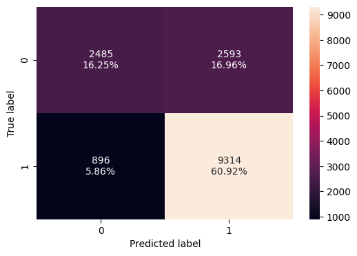

```python
confusion_matrix_sklearn(rf_tuned, X_train, y_train)
```

```python
rf_tuned_model_train_perf = model_performance_classification_sklearn(
    rf_tuned, X_train, y_train
)
rf_tuned_model_train_perf
```

|  | Accuracy | Recall | Precision | F1 |
| --- | --- | --- | --- | --- |
| 0 | 0.771782 | 0.912243 | 0.782229 | 0.842248 |

### Checking model performance on test set

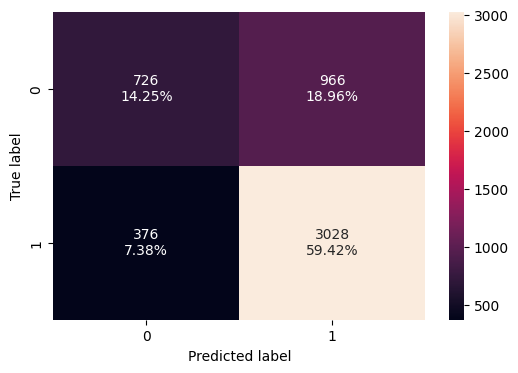

```python
confusion_matrix_sklearn(rf_tuned, X_test, y_test)
```

```python
rf_tuned_model_test_perf = model_performance_classification_sklearn(
    rf_tuned, X_test, y_test
)
rf_tuned_model_test_perf
```

|  | Accuracy | Recall | Precision | F1 |
| --- | --- | --- | --- | --- |
| 0 | 0.736656 | 0.889542 | 0.758137 | 0.8186 |

### Checking model performance on validation set

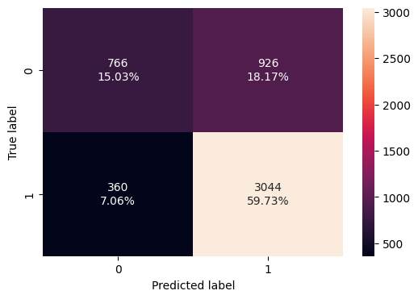

```python
confusion_matrix_sklearn(rf_tuned, X_val, y_val)
```

```python
rf_tuned_model_val_perf = model_performance_classification_sklearn(
    rf_tuned, X_val, y_val
)
rf_tuned_model_val_perf
```

|  | Accuracy | Recall | Precision | F1 |
| --- | --- | --- | --- | --- |
| 0 | 0.747645 | 0.894242 | 0.766751 | 0.825603 |